# lightning_talk

## Aesopbot the freestyling chatbot

### Discord chat bot trained on Aesop Rock's lyrics using LSTM recurrent neural networks

### Why Aesop Rock?

I'm a big fan of his for one, but I also thought it would be interesting to train a bot using his lyrics.

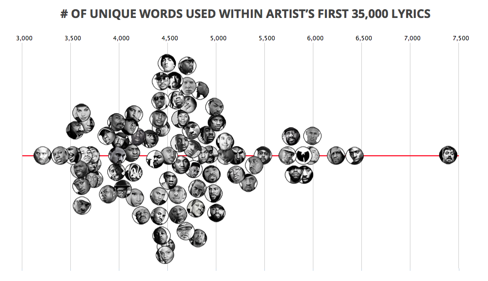

source: Matt Daniels https://mikepultz.com/number-of-unique-words-used-within-artists-first-35000-lyrics-adjusted/

```python
YouTubeVideo('ZEBGCOCxLgA')
```

[video not shown]

```python
import os
import sys
module_path = os.path.abspath(os.path.join('..'))
if module_path not in sys.path:
    sys.path.append(module_path)
sys.path.append(os.path.join(os.path.join('..'), 'data/'))
from src.features.build import Provider, Dataset
# _d = Dataset()

from IPython.display import HTML
from IPython.display import YouTubeVideo
```

### Recurrent Neural Networks (RNNs)

RNN's are a type of neural network used for analyizing time series or sequence based data

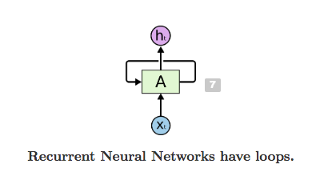

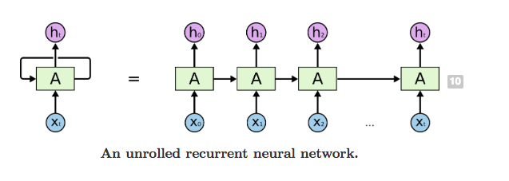

source: http://colah.github.io/posts/2015-08-Understanding-LSTMs/

#### Suffer from long term dependences. As the "gaps" in relavant information grows traditional RNN's start to lose their ability to learn

### Long Short Term Memory (LSTM) Units

Solve this problem by using what are called "gates", which determine what information should be allowed into individual neural units.

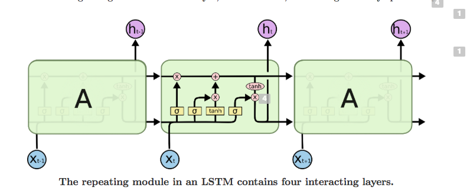

source: http://colah.github.io/posts/2015-08-Understanding-LSTMs/

You cant remember every single second of every day can you?

### Dataset

Used a collected dataset composed of text from MetroLyrics and hosted on Kaggle https://www.kaggle.com/gyani95/380000-lyrics-from-metrolyrics

Filtered dataset to only contain Aesop Rock's lyrics, cleaned up the data, and produced some basic vocab metrics (WIP)

```python
_d.df[_d.df['artist'] == 'aesop-rock'].head()
```

|  | index | song | year | artist | genre | lyrics | lyrics_transform | song_length | unique_words |
| --- | --- | --- | --- | --- | --- | --- | --- | --- | --- |
| 174914 | 174914 | numb-to-the-guns | 2009 | aesop-rock | Hip-Hop | (News Reporter)\natop the news this evening *s... | news reporter \n atop the news this evening st... | 39 | 920 |
| 174915 | 174915 | getaway-car | 2007 | aesop-rock | Hip-Hop | Cage\nYo, I?ll send this to alla my corporate ... | cage \n yo, i ll send this to alla my corporat... | 28 | 504 |
| 174916 | 174916 | limelighters | 2007 | aesop-rock | Hip-Hop | AESOP- Pain cave uno, smoking a broken blue no... | aesop- pain cave uno, smoking a broken blue no... | 35 | 478 |
| 174917 | 174917 | alchemy | 2007 | aesop-rock | Hip-Hop | [Blueprint]\nI spit with an immense amount of ... | blueprint \n i spit with an immense amount of ... | 33 | 701 |
| 174918 | 174918 | no-jumper-cables | 2007 | aesop-rock | Hip-Hop | Burn train buffers\nMy fancy\nUp jumps the boo... | burn train buffers \n my fancy \n up jumps the... | 35 | 878 |

### Training and Model Parameters

Combined lyrics from all songs and divided them into batches of 25 sequences each consisting of 12 words. Given the dataset this resulted in a total of 198 batches per epoch.

Model was ran overnight (about 40,000 total sequences)

Model consists of 2 LSTM layers, each having a total of 512 units. Embedding of words was done via seq2seq and optimization of the cost function was done using the Adam optimizer. (Not enough detail to go into during an LT)

#### Note that this is a word based model

#### Model state is saved after every epoch

### Model Architecture

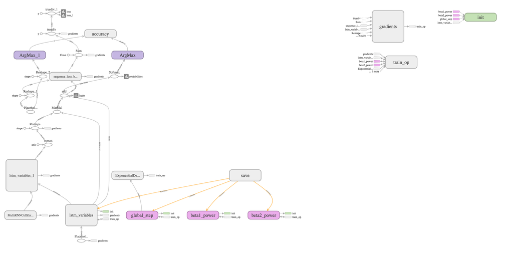

### Chatbot and Text Generation

Chatbot hosted in Discord.

The freestyle command has two inputs, a word and the number of bars you want aesop to rap (1 bar = 12 words)

Aesopbot generates text by inputting the given word to the saved model state.

The model outputs a vector of probabilities with length equal to the total vocabulary of Aesop Rock.

The word with the highest probability is then chosen and appended to the text.

The word chosen is then fed back into the model and so on and so forth until the total number of bars is generated.

The text is then ran through AWS's Polly function to convert it to speech saved as an MP3 file.

```python
#Give it a try with a beat!
YouTubeVideo('jB0g_KHNhh8')
```

[video not shown]